# Sesjon 10: Mer tegning: ggplot2

**Gjennomsiktig farge** Jeg kan oppgi at jeg ønsker gjennomsiktige farger. Dette gjør jeg med argumentet `alpha=`. Verdien jeg oppgir rangerer fra 0 (helt gjennomsiktig/usynlig) til 1 (ikke-transparent).

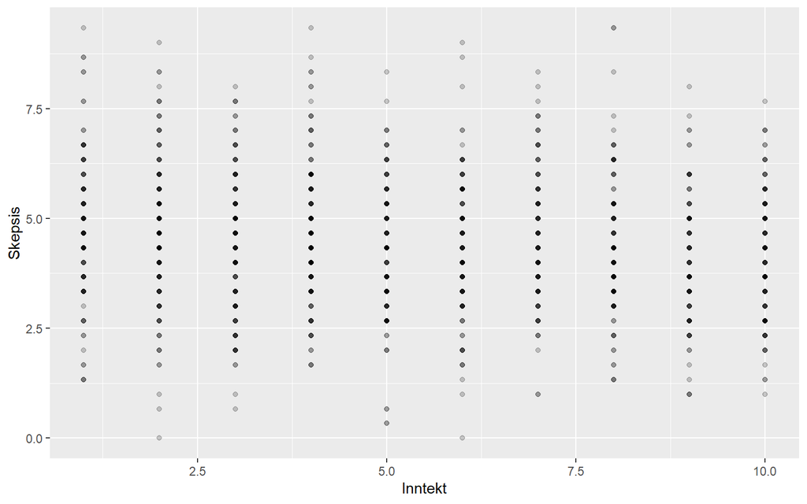

Ved å bruke gjennomsiktig farge, kan jeg vise hvor de fleste observasjonene befinner seg i fordelingen.

```r
ggplot(df) +
  geom_point(aes(y = Skepsis,
                 x = Inntekt),
             #Gjennomsiktighet: for alle observasjoner
             alpha = 0.2)
```

Notér at når vi skal tilrettelegge punktene uten at tilretteleggingen er avhengig av informasjon fra dataene, så foregår dette *utenfor* `aes()` men *innenfor* `geom_...()` funksjonen.

**Riste data** Et annet alternative er å “riste” datapunktene litt. På engelsk kaller vi dette “jitter”. Da legger R til en tilfeldig variasjon i punktenes koordinater. Selve datapunktene blir mer upresise, men poenget her er ikke en presis analyse, men å presentere sammenhenger i dataene slik at det menneskelige øyet får en intuitiv forståelse av hva som foregår.

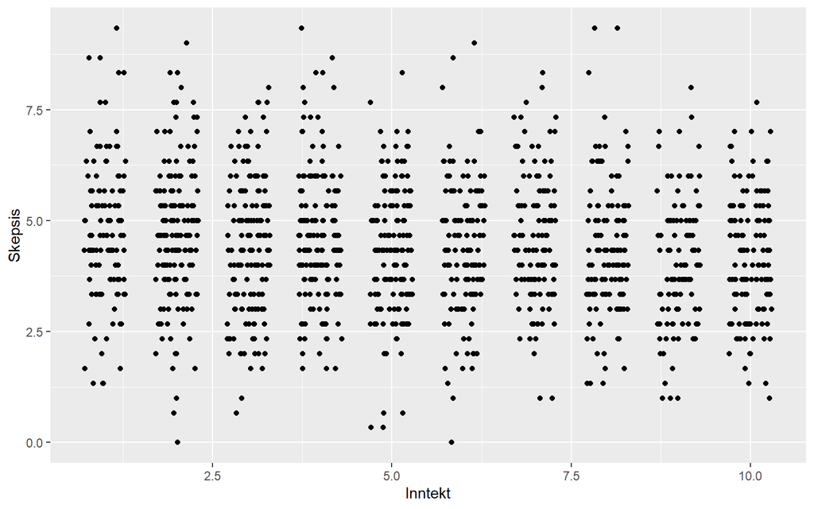

Ved å ‘riste’ datapunktene, kan jeg også gi et bedre inntrykk av hvor observasjonene befinner seg.

```r
ggplot(df) +
  geom_jitter(aes(y = Skepsis,
                 x = Inntekt),
              #Riste data horisontalt, men ikke vertikalt
              height = 0, width = 0.3)
```

Tilleggsargumentene `width=` og `height=` presiserer hvor mye punktene skal ristes horisontalt og vertikalt, respektivt. Her sier jeg at jeg ønsker presise data langs y-aksen (“i høyden”), men lar punktene variere tilfeldig med 0.3 enheter langs x-aksen (“i bredden”).

### Trivariate grafikker: Gruppér dataene.

Jeg kan enkelt legge til flere grupperinger. Her fargelegger jeg punktene etter verdien på en tredje variabel: Den variabelen kan være kontinuerlig eller kategorisk.

**Kontinuerlig gruppering** “Subjektiv inntekt” rapporterer hvor rik respondenten *føler* seg i fire kategorier fra 0 (“lav tilfredshet”) til 3 (“høy tilfredshet”).

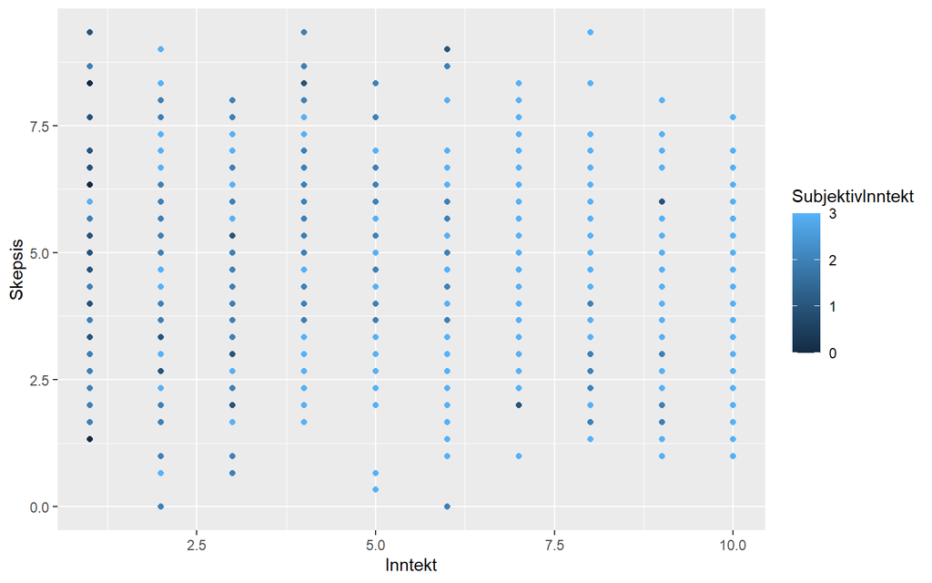

```r
ggplot(df) +
  geom_point(aes(y = Skepsis,
                 x = Inntekt,
                 #Gruppering
                 color = SubjektivInntekt))
```

Nå får jeg en “varmeskala” for respondentens oppfattelse av egen inntekt. ggplot gir oss også automatisk en tegnforklaring.

Her ser vi at de fleste respondentene som rapporterer lav tilfredshet (mørk farge) befinner seg til venstre i plottet. De har lav (objektiv) inntekt.

**Kategorisk gruppering** Skal jeg ha en kategorisk gruppering, må jeg fôre funksjonen inn med en kategorisk variabel (“character” eller “factor”). Det beste er å gjøre dette i plotdataene, ikke i ggplot()-funksjonen. Akkurat her, fraviker jeg fra denne regelen med (`as.factor()`)

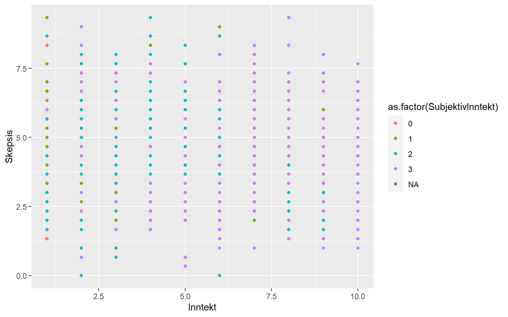

```r
ggplot(df) +
  geom_point(aes(y = Skepsis,
                 x = Inntekt,
                 #Gruppering
                 color = as.factor(SubjektivInntekt)))
```

Én løsning forhindrer ikke en annen. Jeg kan selvsagt kombinere alle disse løsningene fram til jeg får et plot som forteller historien jeg ønsker å formidle.

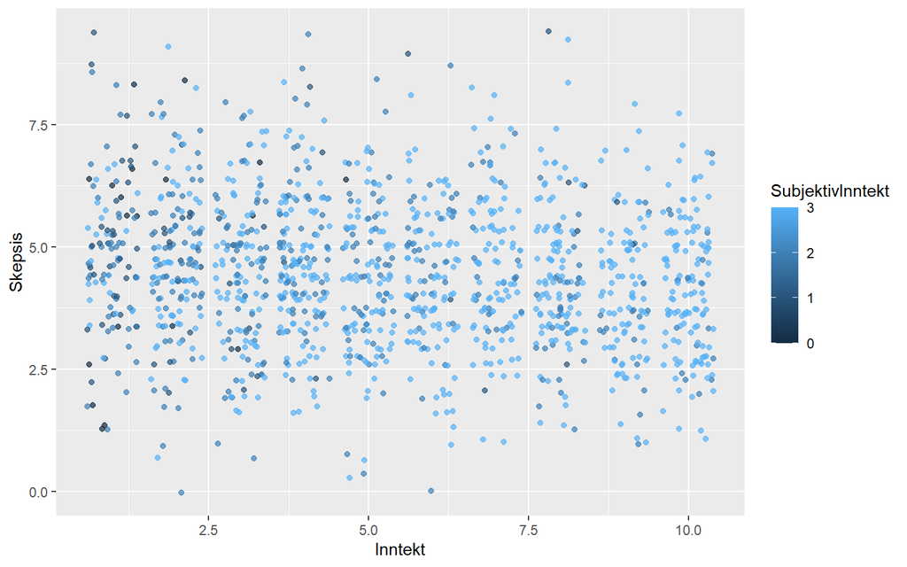

```r
ggplot(df) +
  geom_jitter(aes(y = Skepsis,
                 x = Inntekt,
                 #Kontinuerlig tredje/modererende variabel
                 color = SubjektivInntekt),
              #Riste data horisontalt og vertikalt
              height = 0.1, width = 0.4,
              #Gjennomsiktig farge
              alpha = 0.7)
```

## Bivariate regresjonslinjer

Jeg kan også vise sammenhengen mellom to variabler ved hjelp av regresjonslinjer. ggplot rapporterer ikke regresjonskoeffisientene, men illustrerer i stedet regresjonslinjen og usikkerheten rundt den. Dette er spesielt relevant hvis minst en av variablene (x-variabelen) er kontinuerlig.

Nå kan vi velge mellom lokal regresjon og vanlig lineær regresjon. Hvilken vi velger, avhenger av hva vi vil oppnå.

### Lokal regresjon

Lokal regresjon er – i mine øyne – dronningen av alle ggplot-funksjoner. Jeg bruker den hele tiden når jeg utforsker dataene mine. Den tegner en “myk” linje (lokalt, glidene gjennomsnitt over de ulike x-verdiene). Helt perfekt for tidstrender eller for å utforske ikke-lineære sammenhenger, for eksempel.

Funksjonen som gir oss bivariate regresjonslinjer er `geom_smooth()`. Default-instillingen er lokal regresjon.

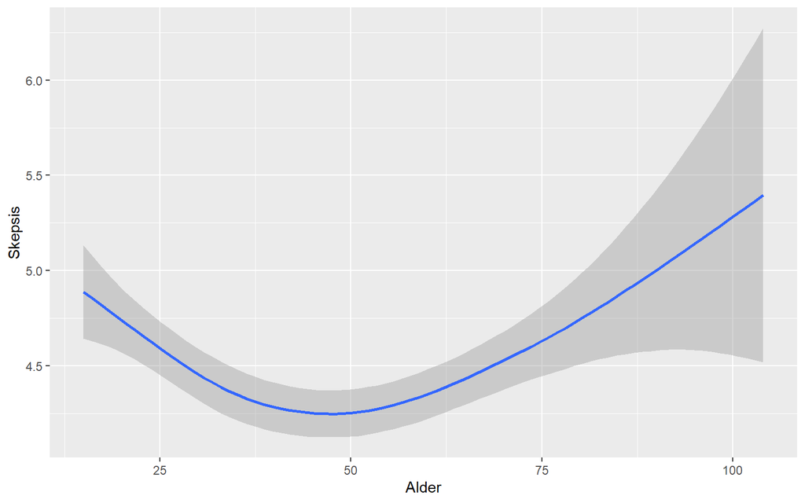

Lokal regresjon: En enkelt måte å presentere empiriske sammenhenger mellom to variabler.

```r
ggplot(df) +
  geom_smooth(aes(y = Skepsis,
                  x = Alder))
```

Her illustrerer jeg sammenhengen mellom alder og innvandringsskepsis. Figuren demonstrerer den største fordelen med lokal regresjon: Det finnes ingen lineær sammenheng mellom alder og innvandringsskepsis. I stedet ser det ut til at yngre og eldre respondenter er mer skeptiske.

R tilpasser “vinduet” automatisk for oss, men vi kan velge størrelsen selv. Da anvender vi tilleggsargumentet `span =`. Hvor stort spenn av variabelen skal brukes for det lokale gjennomsnittet? Lave verdier gir en mer krøllete strek, høye verdier gir mer generalisering.

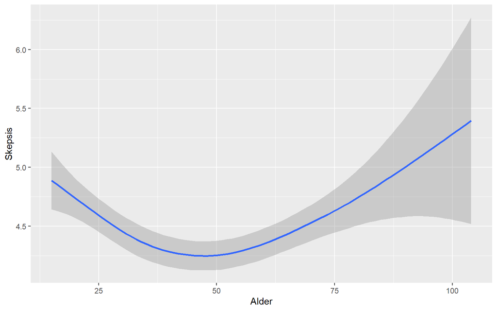

Lokal regresjon: En enkelt måte å presentere bivariat sammenhenger.

```r
ggplot(df) +
  geom_smooth(aes(y = Skepsis,
                  x = Alder),
              span = 20)
```

Gruppert: Er sammenhengen lik innenfor ulike kategorier?

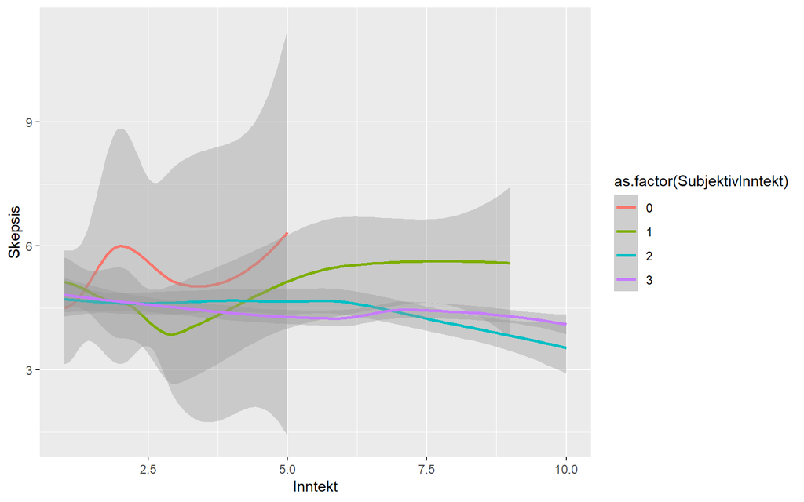

Lokal regresjon: Dronningen av bivariate plot?

```r
ggplot(df) +
  geom_smooth(aes(y = Skepsis,
                  x = Inntekt,
                  color = as.factor(SubjektivInntekt)))
```

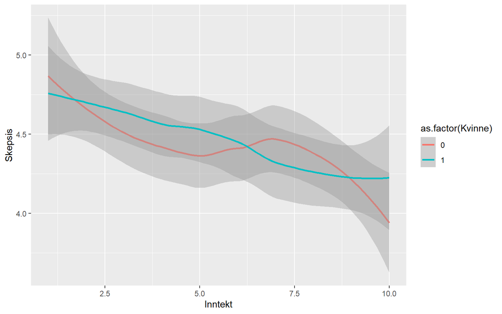

```r
ggplot(df) +
  geom_smooth(aes(y = Skepsis,
                  x = Inntekt,
                  color = as.factor(Kvinne)))
```

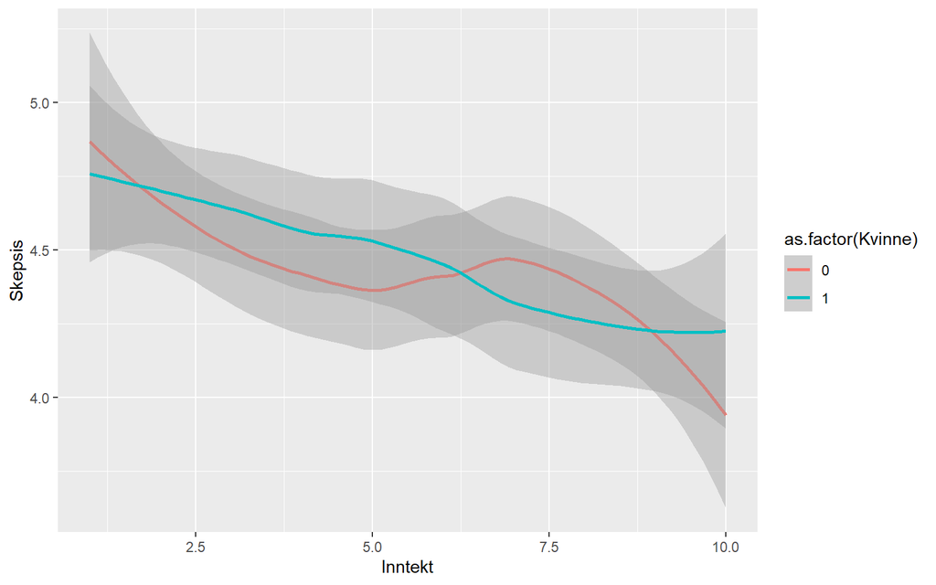

```r
ggplot(df) +
  geom_smooth(aes(y = Skepsis,
                  x = Inntekt,
                  color = as.factor(Kvinne)))
```

Vil du bytte ut spaghettien med rette linjer? Be om en lineær modell.

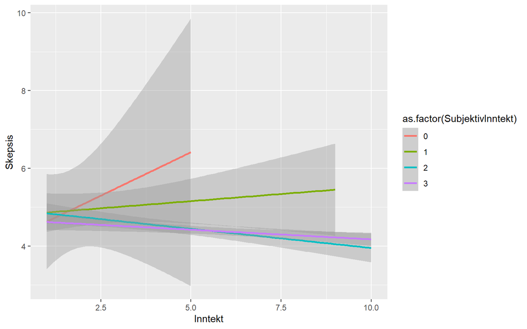

```r
ggplot(df) +
  geom_smooth(aes(y = Skepsis,
                  x = Inntekt,
                  color = as.factor(SubjektivInntekt)),
              method = "lm")
```

## Boksplot

```
## notch went outside hinges. Try setting notch=FALSE.
```

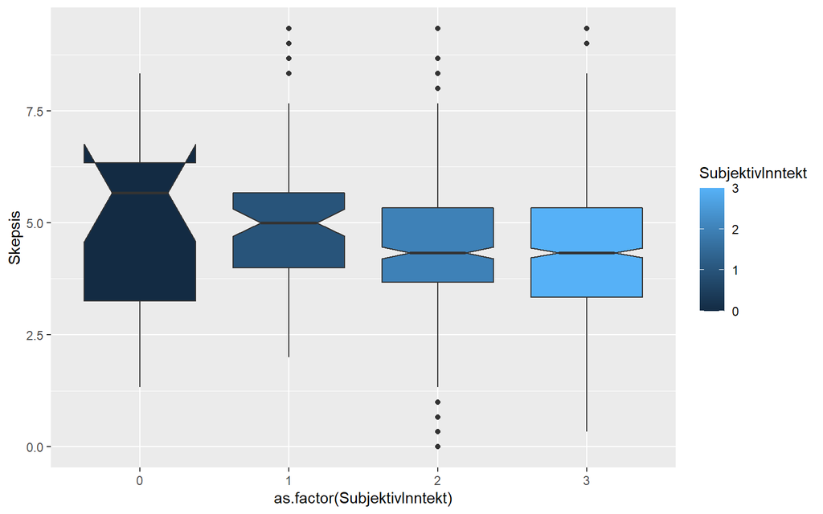

Boksplot gir et inntrykk av fordelingen internt i grupper av data

```r
ggplot(df %>%
         filter(!is.na(SubjektivInntekt))) +
  geom_boxplot(aes(y = Skepsis,
                   x = as.factor(SubjektivInntekt),
                   fill = SubjektivInntekt),
                   notch = T)
```

## Fiolinplot

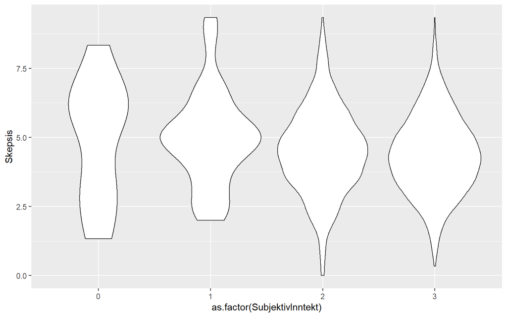

```r
ggplot(df %>%
         filter(!is.na(SubjektivInntekt))) +
  geom_violin(aes(y = Skepsis,
                  x = as.factor(SubjektivInntekt)))
```

## Tetthetsgrafikker

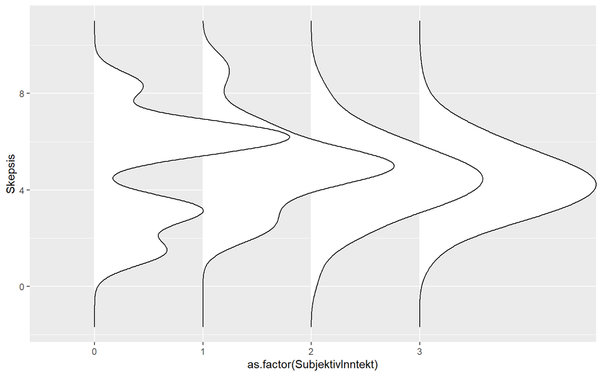

```r
library(ggridges)
ggplot(df %>%
         filter(!is.na(SubjektivInntekt))) +
  geom_density_ridges(aes(x = Skepsis,
                          y = as.factor(SubjektivInntekt)),
                      fill = "white") +
  coord_flip()
```

## Søylediagram/histogram

Søylediagrammet og histogrammet tar minst ett argument: Vi oppgir hvorvidt høyden på søylene skal defineres langs y-aksen (vertikale søyler) ller x-aksen (horisontale søyler). ggplot teller antall observasjoner for oss.

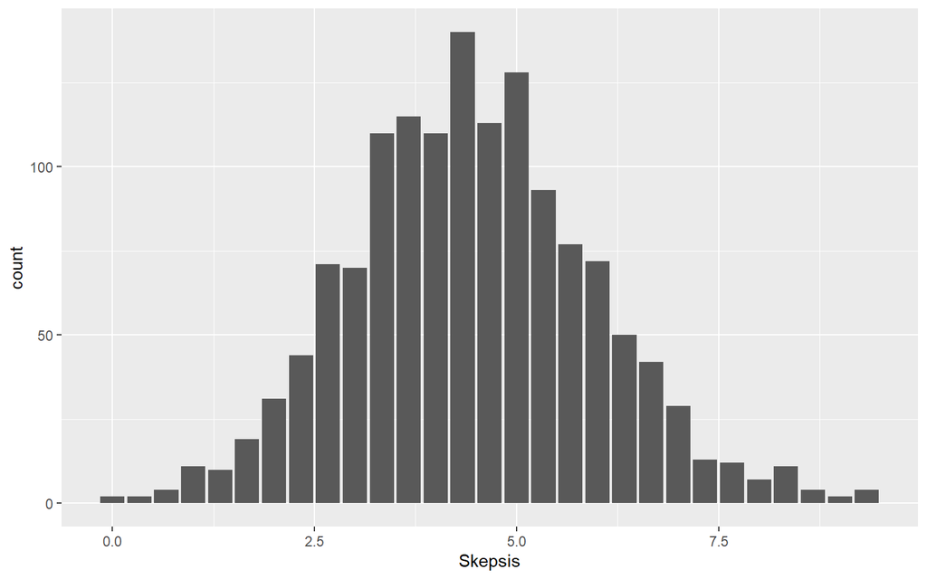

```r
ggplot(df) +
  geom_bar(aes(x = Skepsis))
```

Histogrammet følger samme regler.

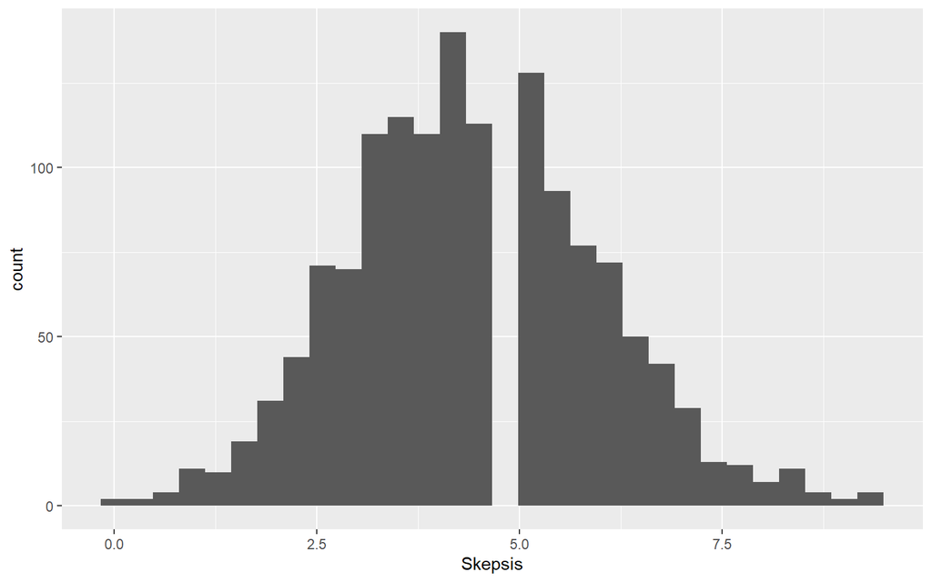

Histogrammer viser den univariate fordelingen til en kontinuerlig variabel.

```r
ggplot(df) +
  geom_histogram(aes(x = Skepsis))
```

Vi kan lage et tetthetsdiagram med samme logikk.

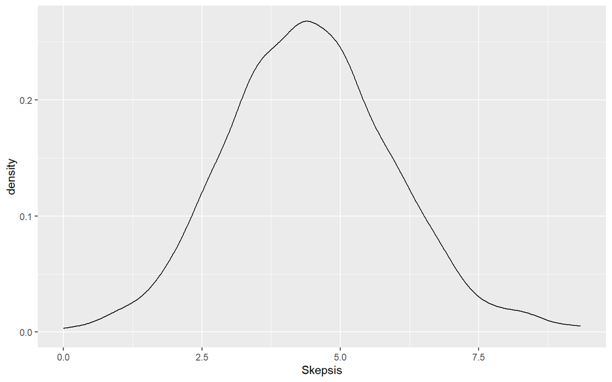

```r
ggplot(df) +
  geom_density(aes(x = Skepsis))
```

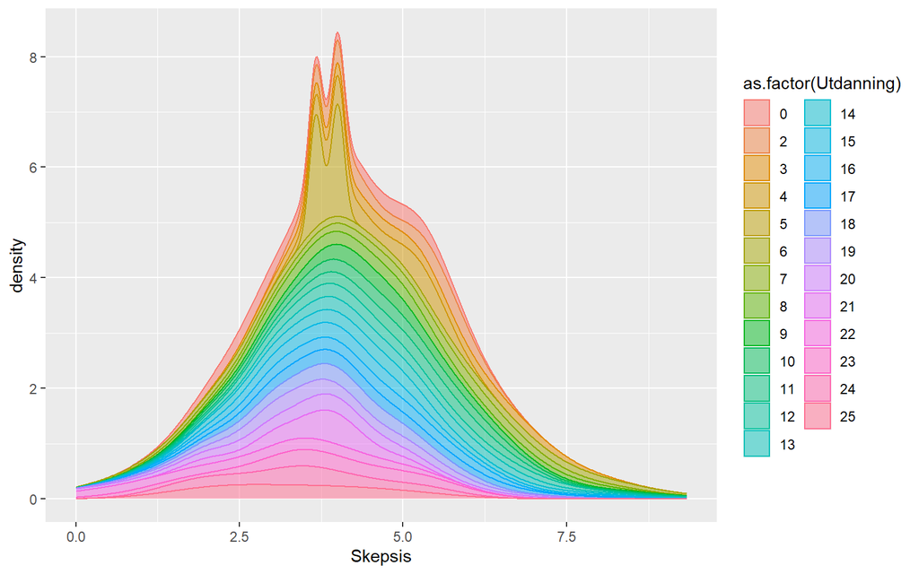

```r
ggplot(df %>% filter(!is.na(SubjektivInntekt))) +
  geom_density(aes(x = Skepsis,
                   color = as.factor(Utdanning),
                   fill = as.factor(Utdanning)),
               position = "stack",
               alpha = 0.5)
```

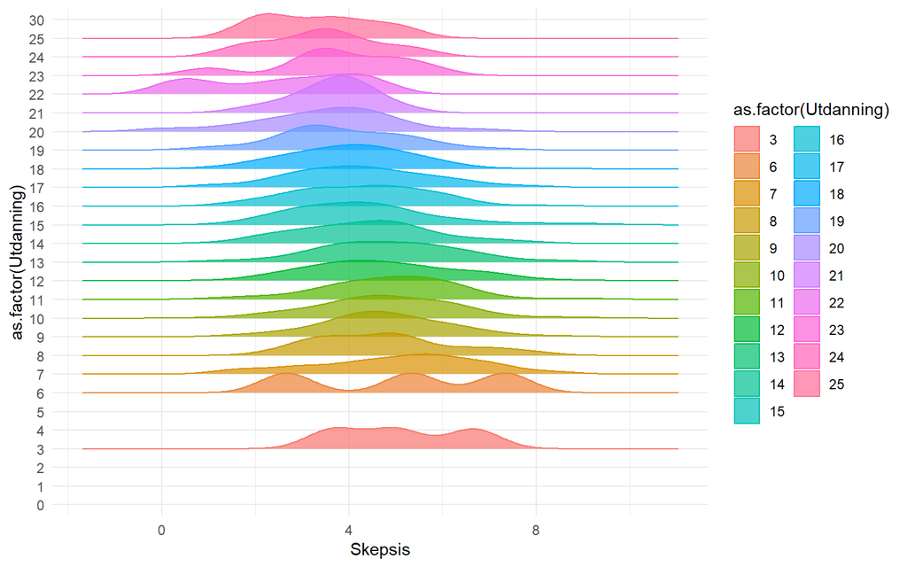

```r
library(ggridges)
ggplot(df %>% filter(!is.na(SubjektivInntekt))) +
  geom_density_ridges(aes(x = Skepsis,
                          y = as.factor(Utdanning),
                          color = as.factor(Utdanning),
                          fill = as.factor(Utdanning)),
                      alpha = 0.7) +
  theme_minimal()
```

## Flere plot:

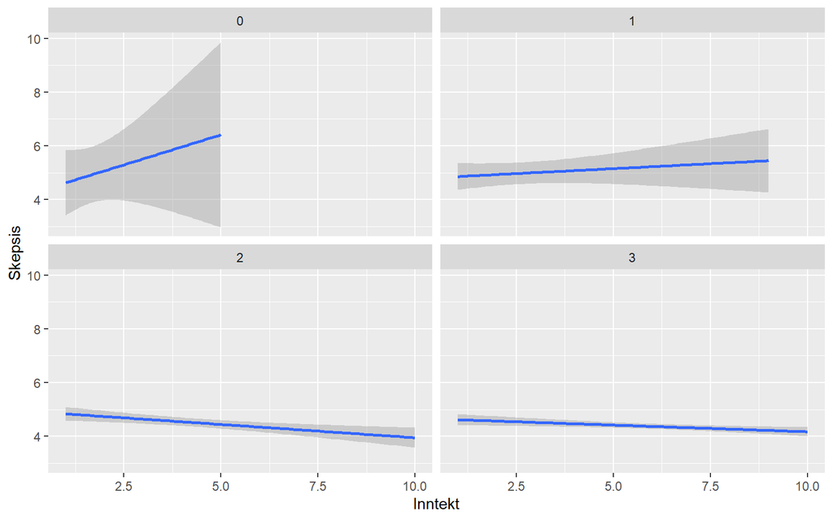

```r
ggplot(df %>%
         filter(!is.na(SubjektivInntekt))) +
  geom_smooth(aes(x = Inntekt,
                  y = Skepsis,
                  group = as.factor(SubjektivInntekt)),
              method = "lm") +
  facet_wrap(facets = vars(SubjektivInntekt))
```

# Lag et grafisk datasett først

La oss følge en alternativ arbeidsflyt og etablere et eget lite datasett for plotting. Her er jeg interessert i innvandringsskepsis blant respondenter med ulik oppfatning av egen inntekt.

```r
dfp <- df %>%
  #Filtrer ut NA
  filter(!is.na(SubjektivInntekt)) %>%
  #Grupper
  group_by(SubjektivInntekt) %>%
  #Gruppegjennomsnitt
  summarize(Innvandringsskepsis = mean(Skepsis, na.rm = T))

#Lag en ny kategorisk variabel med selve survey spørsmålet
dfp$`Hvor godt lever du på inntekten din?` <- dfp$SubjektivInntekt %>%
  as.factor
#Omdefiner kategoriene til intuitive svar
levels(dfp$`Hvor godt lever du på inntekten din?`) <- c("Svært vanskelig",
                                                        "Vanskelig",
                                                        "Endene møtes",
                                                        "Komfortabelt")
```

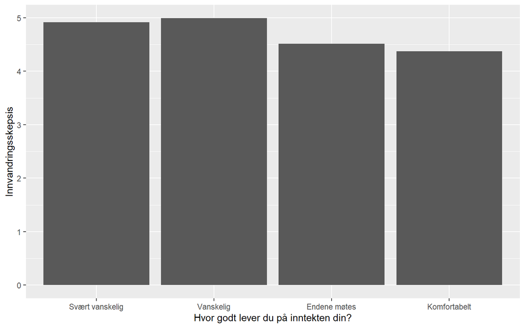

```r
ggplot(dfp) +
  #Klassisk definisjon av både x og y koordinater
  geom_bar(aes(y = Innvandringsskepsis,
               x = `Hvor godt lever du på inntekten din?`),
           #Bruker tallene du oppgir som søylehøyde uten å telle selv.
           stat = "identity")
```

```r
dfp <- df %>%
  #Filtrer ut NA
  filter(!is.na(SubjektivInntekt) &
           !is.na(Prekaritet)) %>%
  #Grupper
  group_by(Prekaritet, SubjektivInntekt) %>%
  #Gruppegjennomsnitt
  summarize(Innvandringsskepsis = mean(Skepsis, na.rm = T))
#Omkod to modrererende variabler
#Lag en ny kategorisk variabel med selve survey spørsmålet
dfp$`Hvor godt lever du på inntekten din?` <- dfp$SubjektivInntekt %>%
  as.factor
#Omdefiner kategoriene til intuitive svar
levels(dfp$`Hvor godt lever du på inntekten din?`) <- c("Svært vanskelig",
                                                        "Vanskelig",
                                                        "Endene møtes",
                                                        "Komfortabelt")
dfp$Arbeidssituasjon = ifelse(dfp$Prekaritet == 1,
                        "Præker", "Trygg")
dfp
```

| Prekaritet | SubjektivInntekt | Innvandringsskepsis | Hvor godt lever du på inntekten din? | Arbeidssituasjon |
| --- | --- | --- | --- | --- |
| 0 | 0 | 5.166667 | Svært vanskelig | Trygg |
| 0 | 1 | 4.810606 | Vanskelig | Trygg |
| 0 | 2 | 4.461443 | Endene møtes | Trygg |
| 0 | 3 | 4.301829 | Komfortabelt | Trygg |
| 1 | 0 | 5.333333 | Svært vanskelig | Præker |
| 1 | 1 | 5.272727 | Vanskelig | Præker |
| 1 | 2 | 4.709302 | Endene møtes | Præker |
| 1 | 3 | 4.758530 | Komfortabelt | Præker |

```r
p <-
  ggplot(dfp) +
  #Klassisk definisjon av både x og y koordinater
  geom_bar(aes(y = Innvandringsskepsis,
               x = `Hvor godt lever du på inntekten din?`,
               #Fyll ut med en farge ut fra grupperingen
               fill = Arbeidssituasjon),
           #Legg soylene ved siden av hverandre
           position = "dodge",
           #Bruker tallene du oppgir som søylehøyde uten å telle selv.
           stat = "identity")
```

Merk deg hvordan jeg har tatt vare på plottet mitt ved å lagre det i et objekt: `p <- ggplot()`. For å se plottet ber jeg om det.

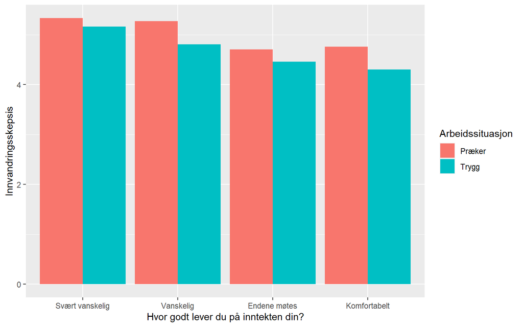

Søylediagram laget av et eget datasett hvor jeg har aggregert og tilrettelagt informasjonen.

```r
p
```

Det er nyttig å lagre objektet på denne måten fordi jeg i det videre skal endre på R-objektet mitt. Det kan jeg gjøre via piper.

# Tilrettelegging.

Når du har lagt inn de grafiske elementene med dataene dine, kan du bruke uendelig tid på å finpusse resten av plottet.

### Fortell R hvilket språk du snakker (og hvor du er)

R er ikke skrevet av nordmenn, så de norske bokstavene kan av og til skape problemer. Vi må forholde oss aktivt til tegnsettingsvalg i to settinger: Når vi henter inn data og når vi lagrer data; inkludert i grafikker.

Datamaskiner leser og gir fra seg informasjon som en serie med 0-er og 1-ere. For å lese og skrive tekst, opererer vi med tegnsetting (“encoding”); en oversettelse av binære koder til alfabetet vi kjenner. Tradisjonelt har hvert land og språk hatt hvert sitt tegnsettingssystem. Det er tungvint, og idag følger det meste av tekst som utveksles på internett, “utf-8”-tegnsetting. Der finnes de aller fleste tegn som vi har lært å lese. `Sys.setlocale()` forteller R hvor du er i verden: Her forteller jeg at jeg ønsker norsk språk med utf-8 tegn.

```r
Sys.setlocale(category = "LC_ALL",
              locale = "nb_NO.UTF-8")
```

## Titler og aksenavn

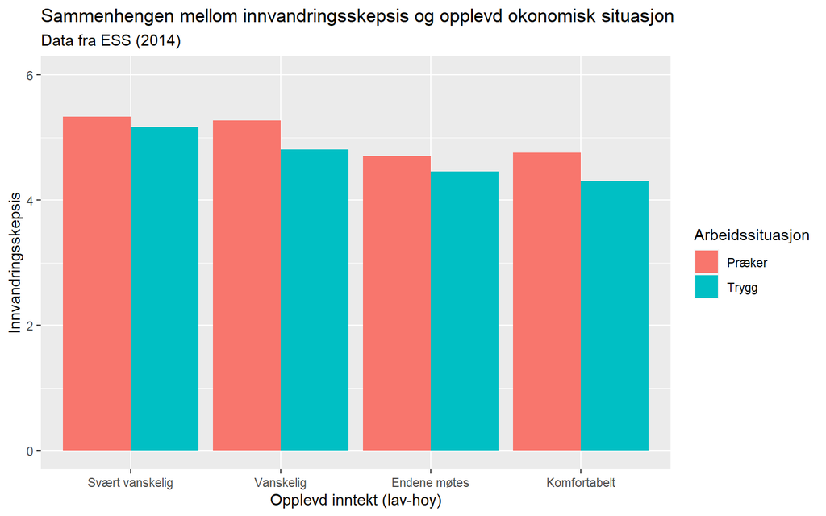

```r
p <-
  p +
  #Legg til tittel og undertittel
  ggtitle(label = "Sammenhengen mellom innvandringsskepsis og opplevd okonomisk situasjon",
          subtitle = "Data fra ESS (2014)") +
  #Navnet på x-aksen
  xlab("Opplevd inntekt (lav-hoy)") +
  #Hva er grenseverdiene for y-aksen?
  ylim(c(0,6))

p
```

## Definer farger

Du kan velge farger selv. Dette gjøres på mange måter. Om du har linket data med fargevalg, kan det være lurt å definere en “palett”.

Selve teksten (“Prekær” og “Trykk”) er en del av dataene jeg oppga, så disse befinner seg i variabelen “dfp$Arbeidssituasjon”. Jeg kan endre dem i ggplot hvis jeg vil. Dette gjør jeg når jeg definerer fargene.

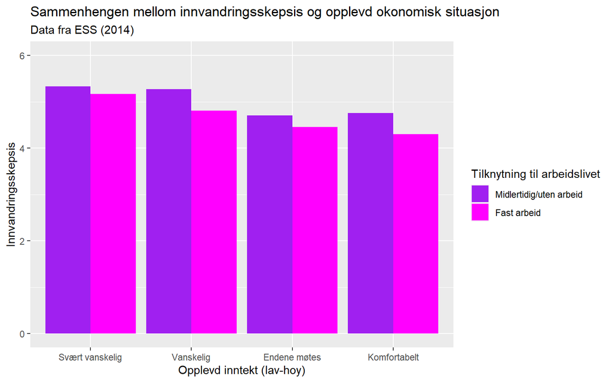

```r
p <-
  p +
  #Definer fargene
  scale_color_manual(
    #Hva er fargene?
    values = c("purple", "magenta"),
    #Fargelegg hele søylen
    aesthetics = "fill",
    #Hva er tittelen for tegnforklaringen?
    name = "Tilknytning til arbeidslivet",
    #Hva er kategorinavnene?
    labels = c("Midlertidig/uten arbeid",
               "Fast arbeid")
    )
p
```

### Bakgrunnen

Du kan definere ulike maler for de estetike delene av plottet med `theme_...()`.

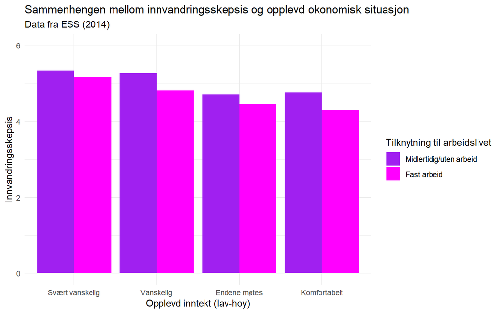

Her bruker jeg ferdig-funksjoner for å endre det visuelle uttrykket til grafikken.

```r
p <-
  p +
  #Definer et tema
  theme_minimal()
p
```

Disse kan du så endre på, hvis du vil.

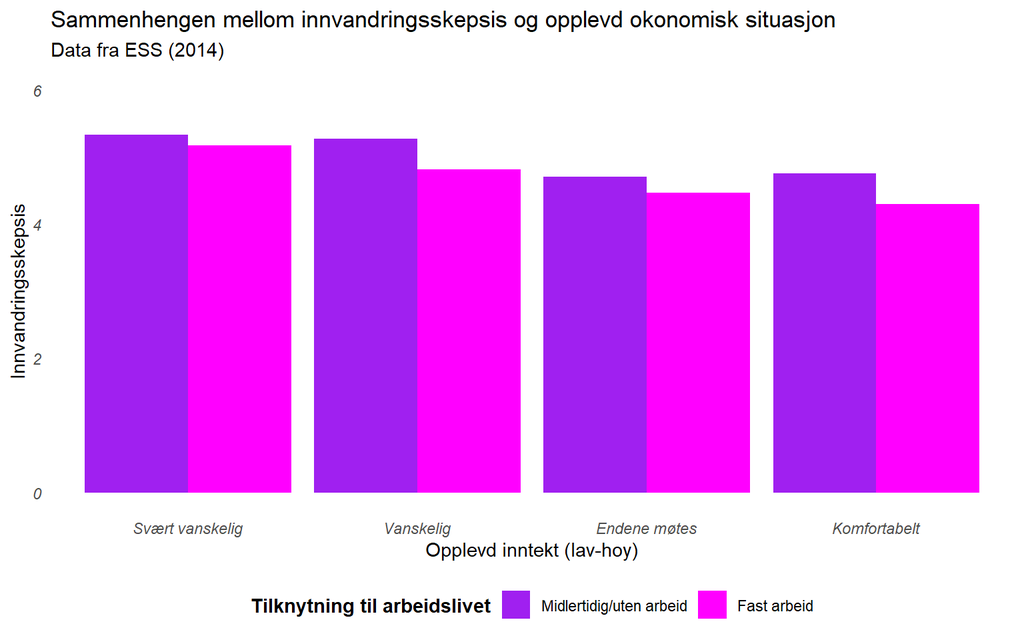

Her har jeg endret bakgrunnen og andre tematiske elementer i grafikken.

```r
p <-
  p +
  #Endre på minimal-temaet etter å ha definert det
  theme(
    #Flytt tegnforklaringen ned til under plottet
    legend.position = "bottom",
    #Fet skrift for tittelen i tegnforklaringen
    legend.title = element_text(face = "bold"),
    #Kursiv for akseverdiene
    axis.text = element_text(face = "italic"),
    #Fjern støttelinjene
    panel.grid = element_blank())
p
```

Funksjonene `element_...()` brukes inni `theme()` funksjonen. De oppgir alt unntatt datainnholdet/informasjonen til et element: Skal det være et blankt element `element_blank()`? Spesifikk skrift? `element_text()` … osv.

Eksempelvis, kan jeg fortelle at teksten som brukes for aksenavnene skal vises som kursiv `element_text(face = "italic")`.